# ISA 616 Workflow

Andrew Bubnar

10/1/2020

# Optimizing Capital Bikeshare Product Distribution

##### An Analysis by Andrew Bubnar

## Overview

I believe that there is room to optimize the distribution process of Capital Bikeshare through predictive modeling. Capital Bikeshare is a bikesharing company, owned by Lyft Inc., that allows registered and casual users to rent public bikes in major cities around the world. Currently, bikes are deployed uniformly over some time dimensions. This creates a lapse in efficiency, that is, bikes are not always available when they need to be, and some bikes are sitting idle, producing no revenue. If we can predict the number of bikes that will be in use at any given time, we will maximize use, and thus profitability.

The purpose of this analysis is, firstly, to deduce what factors impact the outcome of riders. The data that will be considered is primarily related to time, weather, and expected traffic. After concluding the impacts of each variable, suggestions to Capital Bikeshare’s Logistics Controls team will be made (and passed along to distributors), to allow for a more satisfied customer base and increased profitabilty.

## Data Selection, Description and Summary

#### Data Head & Codebook

```
##   instant   dteday season yr mnth hr holiday weekday workingday weathersit temp
## 1       1 1/1/2011      1  0    1  0       0       6          0          1 0.24
## 2       2 1/1/2011      1  0    1  1       0       6          0          1 0.22
## 3       3 1/1/2011      1  0    1  2       0       6          0          1 0.22
## 4       4 1/1/2011      1  0    1  3       0       6          0          1 0.24
## 5       5 1/1/2011      1  0    1  4       0       6          0          1 0.24
## 6       6 1/1/2011      1  0    1  5       0       6          0          2 0.24
##    atemp  hum windspeed casual registered cnt
## 1 0.2879 0.81    0.0000      3         13  16
## 2 0.2727 0.80    0.0000      8         32  40
## 3 0.2727 0.80    0.0000      5         27  32
## 4 0.2879 0.75    0.0000      3         10  13
## 5 0.2879 0.75    0.0000      0          1   1
## 6 0.2576 0.75    0.0896      0          1   1
```

```r
# Display a Data Table to Display Descriptions
DT::datatable(desc, colnames="")
```

| instant | Observation # |
| --- | --- |
| dteday | Date |
| season | Season (1 = Spring, 2=Summer, etc.) |
| yr | Year (0 = 2011, 1 = 2012) |
| mnth | Month (numeric) |
| hr | Hour (0 = 12:00 am - 12:59 am, 23 = 11:00pm - 11:59 pm) |
| holiday | Public Holiday (Base 0 = no) |
| weekday | Day of Week (Sunday = 0) |
| workingday | Work Day (non-holiday, weekday) |
| weathersit | Weather Condition (1 = Clear/Parly Cloudy, 2 = Mist/Cloudy, 3 = Light Snow/Rain, 4 = Heavy Rain/Snow/Thunderstorm |

[output cut: 7 more lines]

#### Data Structure

The columns are comprised of a primary key for each observation, the date, 12 predictor variables and three response variables. The three response variables are the amount of casual riders, the amount of registered riders, and the sum of these, total riders.

#### Data Missingness

There is no missing data in the dataset, which provides some ease in the next step, Data Processing

```r
# Count missing data for each column
missing = as.data.frame(sapply(hourly, function(x) sum(is.na(x))))
DT::datatable(missing, colnames =c('Variable', 'Count of Missing'))
```

| Variable | Count of Missing |
| --- | --- |
| instant | 0 |
| dteday | 0 |
| season | 0 |
| yr | 0 |
| mnth | 0 |
| hr | 0 |
| holiday | 0 |
| weekday | 0 |
| workingday | 0 |
| weathersit | 0 |

[output cut: 7 more lines]

## Data Preparation

As this data was already preprocessed for the most part, as it is part of a competition dataset, there was not a lot of processing to do. The one thing that was necessary after importing the data into R was to make sure all the variables were of the right class. The following variables were converted to factors, from their original class of integer:

- Season
- Year
- Month
- Holiday
- Weekday
- Working Day

The other variables that needed to be considered for transformation were ID and Date. These two variables technically hold the same information, the ID field being in integer form, and the Date field being in Date String form. It is to be expected that there is a substantial daily, weekly and yearly seasonal component to the time series, but it is worth noting that there is also a substantial, positive trend component, as is show below.

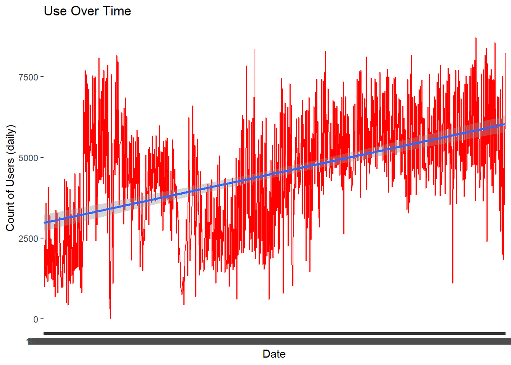

```r
# Create a ggplot to display minimal continuous trend in Users over Time
df = ggplot(data = daily, aes(x=dteday, y=cnt, group = 10)) + geom_line(color="red") + labs(title = "Use Over Time", x = "Date", y = "Count of Users (daily)") + geom_smooth(method = "lm")
df
```

Due to this, I decided to use the ID variable as a count of days and removed the date variable. In the hourly dataset, I chose to alter the ID variable by dividing it by 24 and rounding up, resulting in the same value relative to date. This will allow me to include the trend component without having daily seasonality impede on the value of the variable.

Coding the variables this way will now allow me to analyze each level of time (Hour, Weekday, Month, Year) as factors, and also as a continuous time series aggregated by day.

## Modeling

The purpose of this model is to predict bike use on both an hourly and daily basis, and to determine which factors play substantial, scientifically meaningful roles at each level. To do this, I’ve conducted many predictive linear models that take into account different combinations of predictor variables. Ideally, the most competent model will be one that has the lowest `RMSE`, i.e. average error in predicted bike use for a given time. Another key statistic that I observed was the `coefficient of determination`, which determines the percentage of variation in bike use that is in direct response to changes in the predictors. Maximizing this will also ensure higher quality predictions.

For reference and understanding, I’ve included summary statistics for each variables simple linear regression model:

|  | R-Squared | Adj. R-Squared | Sigma | T-Stat | P-Value | df |
| --- | --- | --- | --- | --- | --- | --- |
| day | 0.374219274481549 | 0.372992253451121 | 1519.54403901298 | 304.981956463219 | 7.04090428944521e-54 | 1 |
| season | 0.328108287790436 | 0.324140423348253 | 1577.62970130786 | 82.691405558695 | 1.41017321835649e-43 | 3 |
| yr | 0.305283829248541 | 0.30392164067844 | 1601.05371985284 | 224.112752044255 | 2.91453881712301e-42 | 1 |
| mnth | 0.383381828809379 | 0.369816229043185 | 1523.38770195786 | 28.2613253683623 | 5.44844433929318e-46 | 11 |
| holiday | 0.00357191033588962 | 0.00161812976792086 | 1917.45500222697 | 1.82820445368795 | 0.176939050606675 | 1 |
| weekday | 0.0166225321218156 | 0.00493883943415407 | 1914.26353063714 | 1.42271219948892 | 0.203816548341084 | 6 |
| workingday | 0.000387538603424544 | -0.00157248583068648 | 1920.51644693624 | 0.197721312387787 | 0.656755097294704 | 1 |
| weathersit | 0.107568652997805 | 0.104062046526283 | 1816.4180344769 | 30.6759979688096 | 2.63809746117725e-13 | 2 |
| temp | 0.382496715196227 | 0.38128592444171 | 1509.4607895197 | 315.906537747512 | 2.33498355906362e-55 | 1 |
| atemp | 0.384189877564368 | 0.382982406736063 | 1507.38993692977 | 318.177357629109 | 1.15680433442135e-55 | 1 |

[output cut: 2 more lines]

As you can see, there are some pretty useless independent variables in this dataset, such as “Weekday”, “Working Day” and “Holiday”. Knowing this made the process of creating my final model much easier.

## Final Model and Justification

After building many models that considered all the variables available, as well as interactive and multiplicative variables, the final two models that will be presented to Capital Bikeshare are as follows:

- A simple linear regression model that predicts average user by time
- A multiple linear regression model that predicts the average users per day based on a combination of conditions

The summary statistics for the models as a whole are:

```r
# Create Data Tables to Display Summary Stats
DT::datatable(as.data.frame(glance(hourmodel)[1:6]))
```

|  | r.squared | adj.r.squared | sigma | statistic | p.value | df |
| --- | --- | --- | --- | --- | --- | --- |
| 1 | 0.498514658381243 | 0.497564640849142 | 129.052528066391 | 524.742587938407 | 0 | 23 |

```r
DT::datatable(as.data.frame(glance(model)[1:6],RMSE))
```

|  | r.squared | adj.r.squared | sigma | statistic | p.value | df |
| --- | --- | --- | --- | --- | --- | --- |
| 1 | 0.822846689398328 | 0.81563066859989 | 823.988552810252 | 114.030531837763 | 5.499710984744e-170 | 20 |

And the summary statistics for each individual variable within the models:

| **Characteristic** | **Beta** | **95% CI**<sup>1</sup> | **p-value** |
| --- | --- | --- | --- |
| hourly.train$hr |  |  |  |
| 0 | — | — |  |
| 1 | -21 | -37, -5.5 | 0.008 |
| 2 | -32 | -48, -16 | <0.001 |
| 3 | -43 | -59, -27 | <0.001 |
| 4 | -48 | -65, -32 | <0.001 |
| 5 | -34 | -50, -18 | <0.001 |
| 6 | 24 | 8.0, 39 | 0.003 |
| 7 | 163 | 147, 179 | <0.001 |
| 8 | 302 | 286, 318 | <0.001 |
| 9 | 166 | 150, 182 | <0.001 |
| 10 | 117 | 101, 133 | <0.001 |
| 11 | 155 | 139, 171 | <0.001 |
| 12 | 200 | 184, 215 | <0.001 |
| 13 | 193 | 177, 209 | <0.001 |
| 14 | 187 | 171, 203 | <0.001 |
| 15 | 197 | 181, 213 | <0.001 |
| 16 | 257 | 241, 273 | <0.001 |
| 17 | 417 | 401, 434 | <0.001 |
| 18 | 376 | 360, 392 | <0.001 |
| 19 | 264 | 248, 280 | <0.001 |
| 20 | 170 | 154, 185 | <0.001 |
| 21 | 120 | 104, 136 | <0.001 |
| 22 | 78 | 62, 94 | <0.001 |
| 23 | 32 | 16, 48 | <0.001 |

<sup>*1*</sup> CI = Confidence Interval

| **Characteristic** | **Beta** | **95% CI**<sup>1</sup> | **p-value** |
| --- | --- | --- | --- |
| day | 5.6 | 5.2, 6.0 | <0.001 |
| season |  |  |  |
| 1 | — | — |  |
| 2 | 826 | 359, 1,294 | <0.001 |
| 3 | 630 | 99, 1,162 | 0.020 |
| 4 | 1,340 | 887, 1,793 | <0.001 |
| weathersit |  |  |  |
| 1 | — | — |  |
| 2 | -374 | -573, -176 | <0.001 |
| 3 | -1,737 | -2,255, -1,219 | <0.001 |
| atemp | 4,622 | 3,514, 5,730 | <0.001 |
| hum | -1,829 | -2,598, -1,059 | <0.001 |
| windspeed | -2,890 | -3,928, -1,852 | <0.001 |
| mnth |  |  |  |
| 1 | — | — |  |
| 2 | -5.8 | -376, 364 | >0.9 |
| 3 | 365 | -69, 799 | 0.10 |
| 4 | 35 | -604, 674 | >0.9 |
| 5 | 326 | -351, 1,002 | 0.3 |
| 6 | -3.5 | -702, 695 | >0.9 |
| 7 | -599 | -1,363, 164 | 0.12 |
| 8 | -269 | -1,002, 464 | 0.5 |
| 9 | 52 | -605, 709 | 0.9 |
| 10 | -665 | -1,277, -52 | 0.034 |
| 11 | -1,717 | -2,318, -1,116 | <0.001 |
| 12 | -1,777 | -2,252, -1,302 | <0.001 |

<sup>*1*</sup> CI = Confidence Interval

Below you can see the the impact of hour of the day independent from other variables:

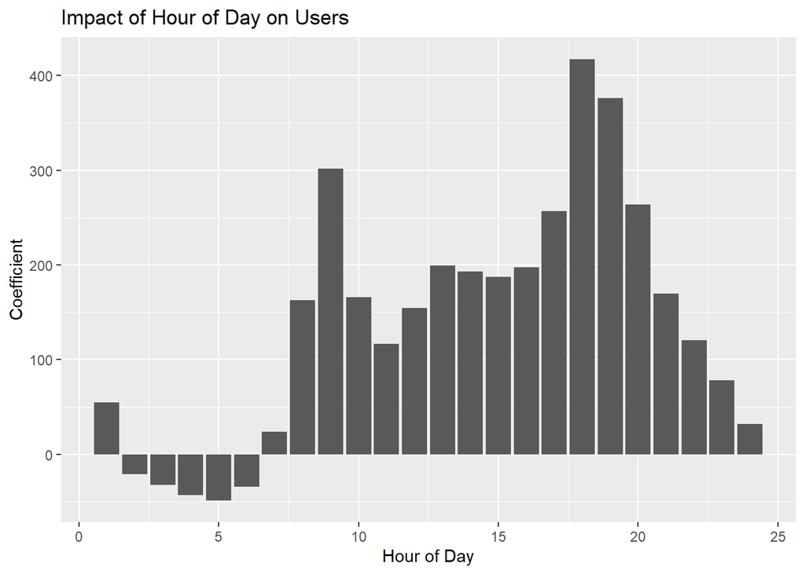

```r
# Plot displays impact of hour of the day on users
ggplot(data = statdf, mapping = aes(x = seq(1,length(hourmodel$coefficients)), y = hourmodel$coefficients)) + geom_bar(position = "dodge", stat = "identity")+ xlab("Hour of Day") + ylab ("Coefficient") + ggtitle("Impact of Hour of Day on Users")
```

#### Justification

The two models created above, when used together, hold extensive power in deciding when Capital Bikeshare should be deploying their bikes for optimal use and warehousing.

## Interpretation and Conclusion

My suggestion to Capital BikeShare is twofold:

Firstly, deploy the amount of bikes that the predictive model suggests each day. This will be somewhat routine, as a lot of the variation is seasonal, and thus, staffing hours can be adjusted to accomodate for these seasonal changes.

If Capital Bikeshare manages to implement these two suggestions, cost savings and revenue increases will be certain.